# Pore size and Coordination number

Thejasvi Beleyur

2020-03-08

## Pore size and Coordination number

This notebook will visualise image analysis data from the Murthy lab. Saurabh looked at the pore sizes and coordination numbers of the stego webs across group size and time. To ensure the plots in the paper look the same - I will be re-plotting the data in ggplot2, and try to perform the same nparLD analyses on the data as I did for the previous data I extracted (total silk length , density).

### Visualising the data

```r
library(readxl)
library(ggplot2)
library(stringr)
library(R.matlab)
data_file <- file.path('pore_size_and_coordination_number_data','Results.xlsx')

# each web's mean pore size + coordination number data is saved as a separate sheet
sheet_names <- excel_sheets(data_file)
sheet_names
```

```
##  [1] "10A" "10B" "10C" "10D" "10E" "10F" "10G" "1A"  "1B"  "1C"  "1D"  "1F"
## [13] "1G"  "25A" "25D" "25E" "25F" "25G" "25H" "5A"  "5E"  "5F"  "5H"
```

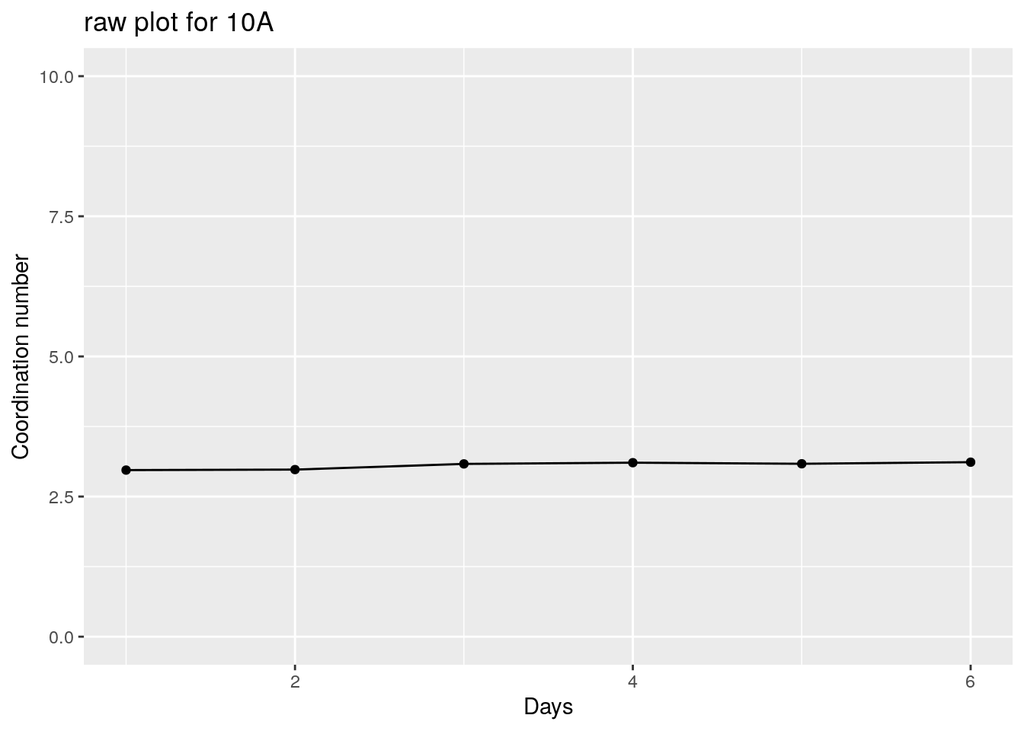

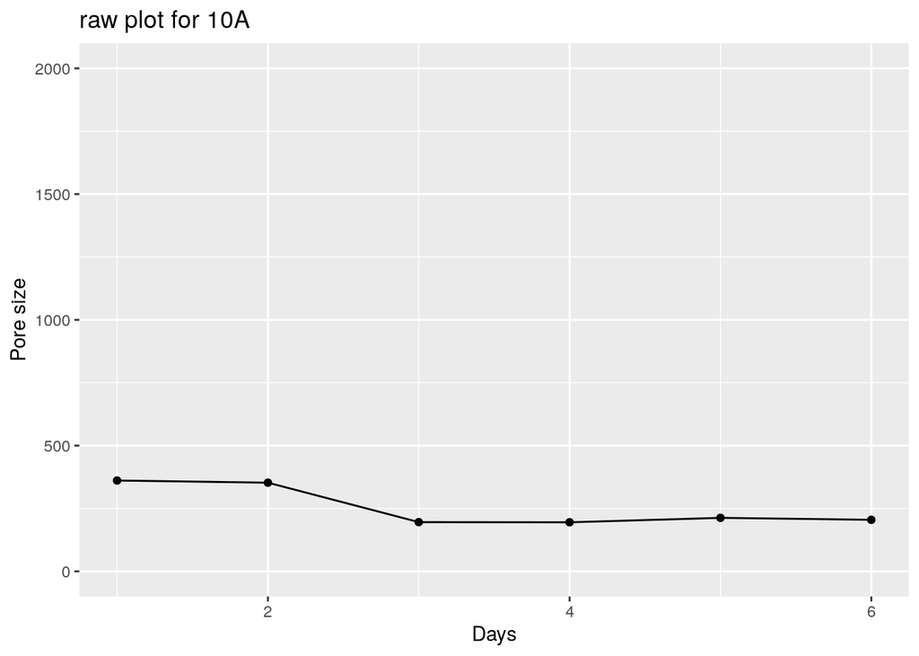

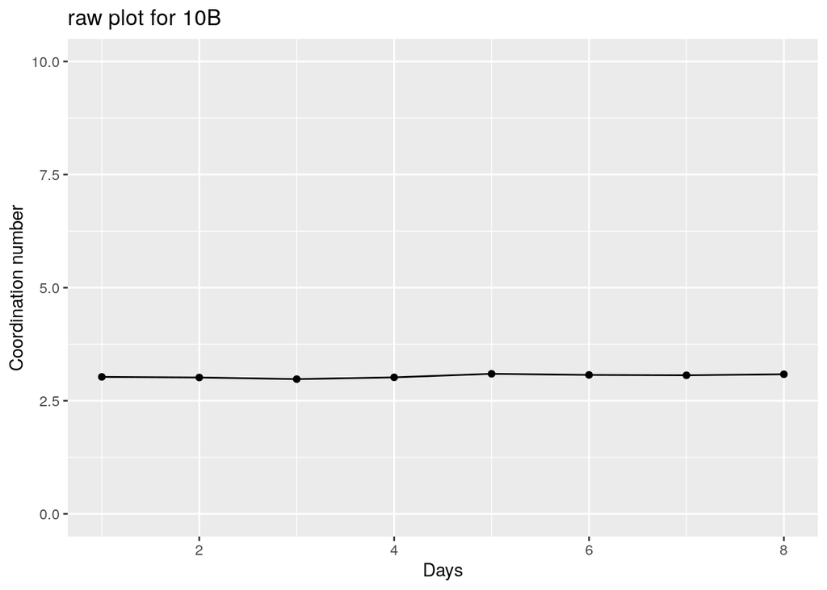

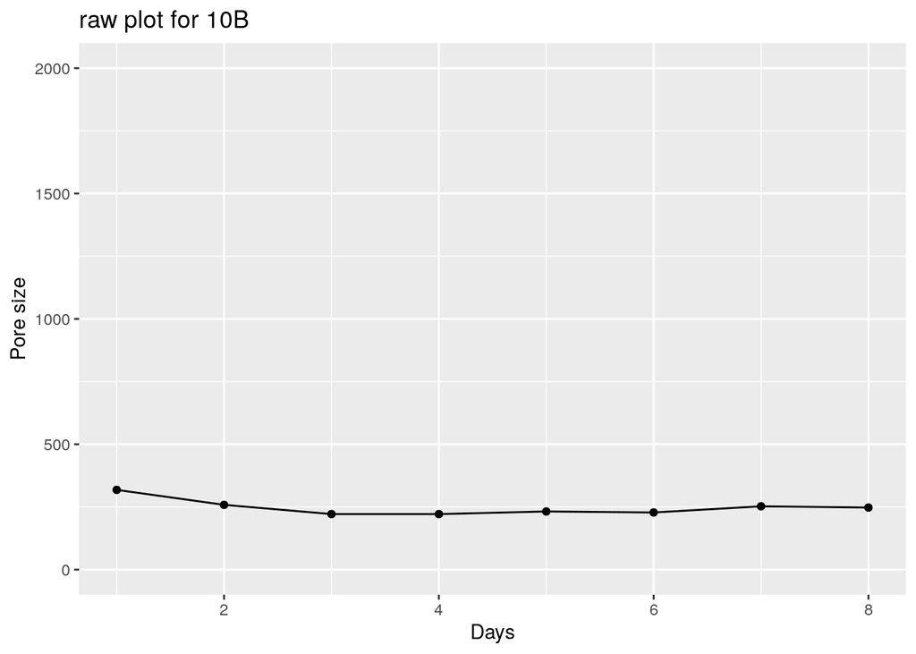

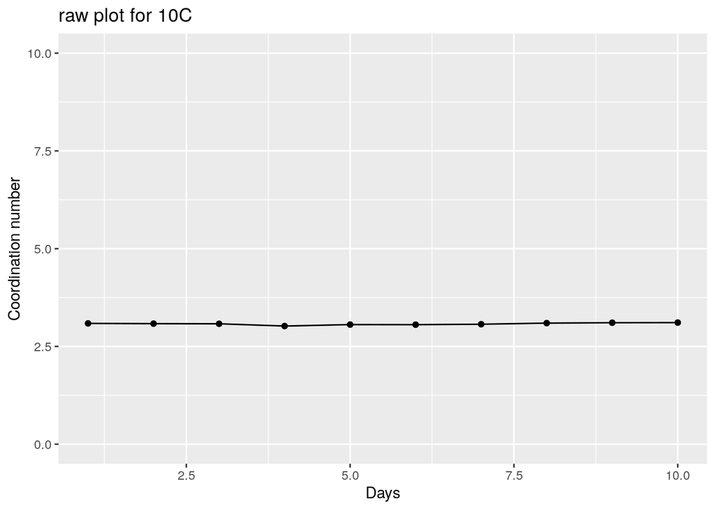

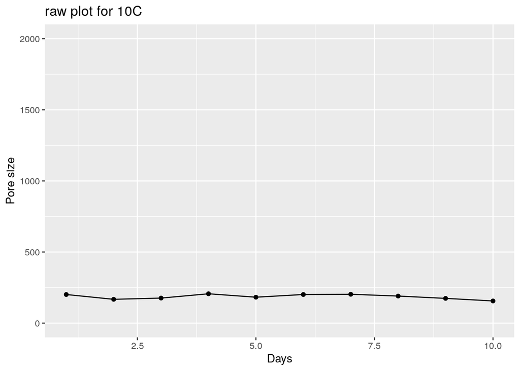

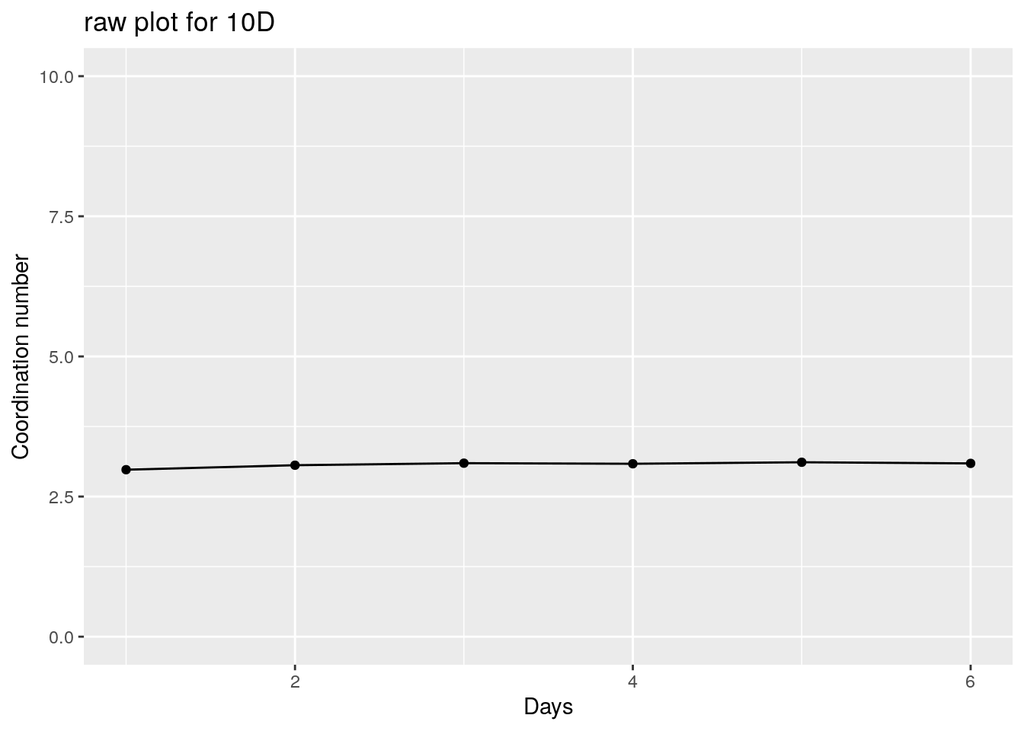

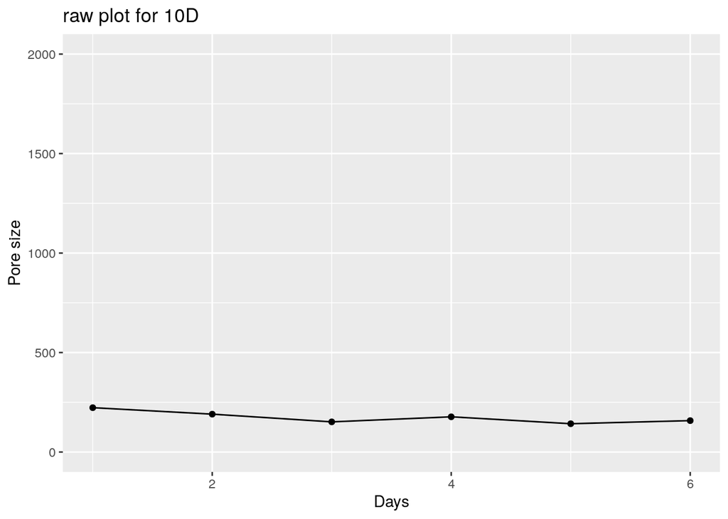

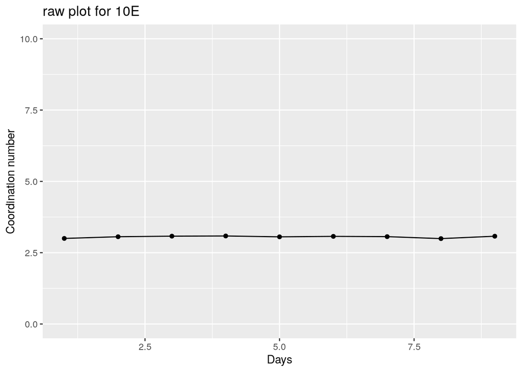

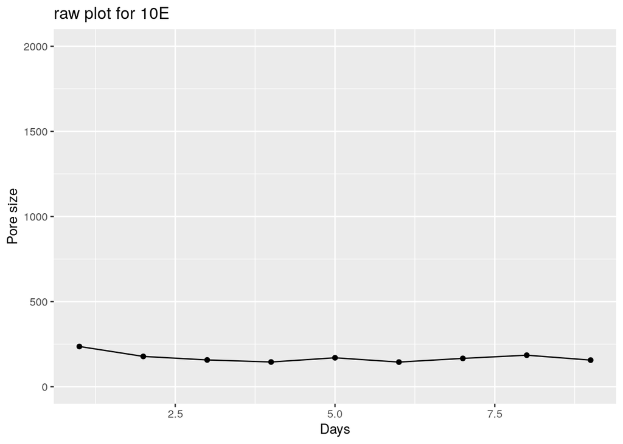

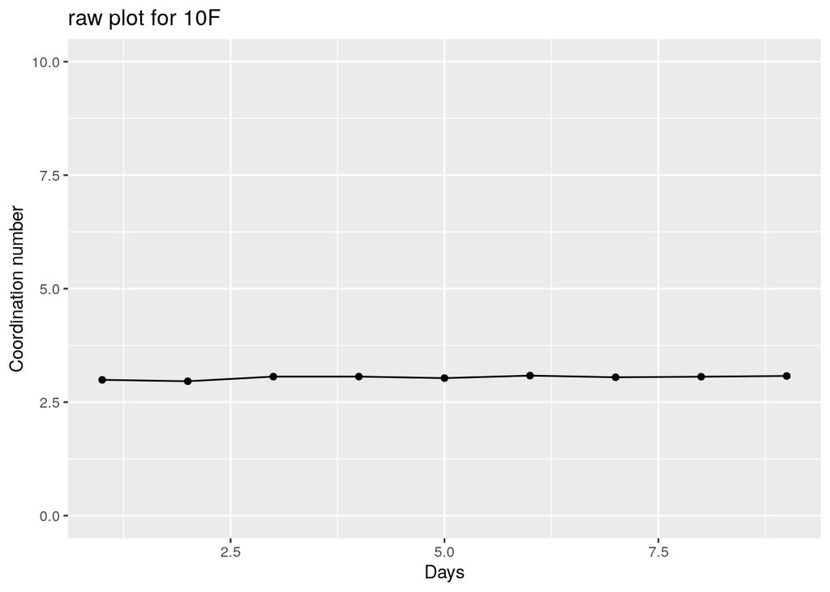

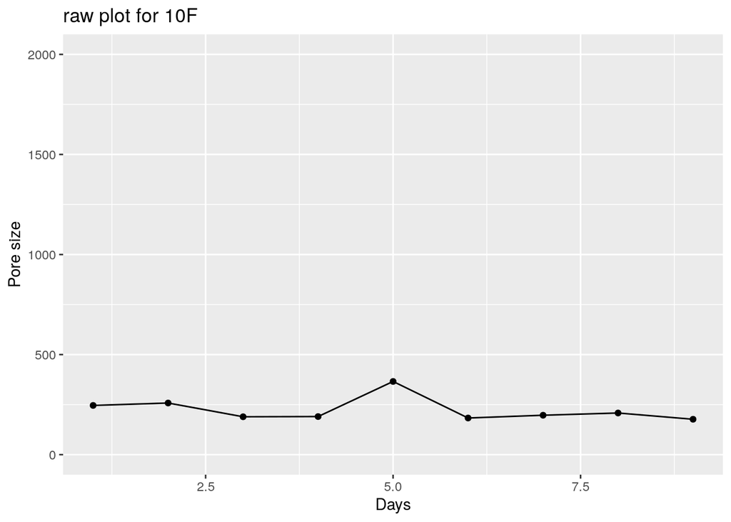

[34 more figures not shown]

```r
# load one example dataset and create a plot of the pore size (PS) and coordination number (CN)
for(example_sheet in sheet_names)
{
example_sheet
eg_data <- read_excel(data_file, sheet=example_sheet)

# plot raw data for Coordination number
cn_days<-ggplot(eg_data, aes(Days, CN) )+geom_point()+geom_line() +ylab('Coordination number') + xlab('Days') + ggtitle(sprintf('raw plot for %s',example_sheet))+ylim(0,10)
print(cn_days)

poresize_days<-ggplot(eg_data, aes(Days, Pores) )+geom_point()+geom_line() +ylab('Pore size') + xlab('Days') + ggtitle(sprintf('raw plot for %s',example_sheet))+ylim(0,2000)
print(poresize_days)


}
```

### 2020-03-08: Something odd with 1C: I just noticed that there’s something a bit odd with 1C’s first and last coordination values. Both the first and last values are 1. I’m guessing a coordination number of 1 means that there’s no strings crossing – or that there’s 2 of them at a junction. Either way the value of 1 is odd/unlikely because the remaining values are at ~2.5, and then on the last day, the coordination number drops to 1. The drop implies a sudden drastic change in structure - which is not seen in the images. I’m guessing this is a typo or an issue with the noisy image interacting with the code. Have written to Saurabh. If the images aren’t clear, the data points could either be removed or corrected. Am waiting for a clarification - until then , however, I’m still going to get the code ready.

### 2020-04-07: Updates and responses from Saurabh

#### 1. Weird trapezoidal pattern in 1C (up, flat and then down back to starting value)

I’d written to Saurabh about the weird data patterns in 1C, and he’s replied just about month ago now. It seems to be an issue with how the images were numbered.

*“The confusion in 1c is caused because of the wrong numbering of original images. The original images are attached in images.zip. You can see for 1c, the web is fully developed for image 1 and least for 91. I had changed the numbering (in reverse order). So the first image does not have any pore or closed polygon which means the pore area can not be calculated. The coordination number of 1, on the other hand, comes from the two segregated silk strands on the left and topside. Further, there are only 10 images so the 11 entry of coordination number 1 is an error. This error happened in renumbering the image. So, you can remove the 11th entry.”*

#### 2. Using the raw data instead of mean values

I’d noticed that using the mean value per web per day basically meant that outliers had a particularly strong effect on the trends. I’d asked Saurabh to send the original values to play around with. He has sent them in the folder titled *ImagesWithResults.zip* on 2020-03-09. The zipped folder has one subfolder for each web. Within this subfolder, there is a results file with a series of probe images with the centre of each cell plotted over it.

#### 3. Using a common ‘probe size’ across $\geq 5$ group sizes

The previous dataset had used a small probe size for single spiders (125x125), and a medium probe size for group sizes 5 & 10 (300x300) and a large probe size for 25 spiders (500x500). I then asked Saurabh to re-analyse the 25 spider group with a probe size of 300x300 pixels to avoid sampling biases. He has sent the results for 25 spider webs with 300x300 probe sizes too in the file *“Results.xlsx”* on 2020-03-15 11:09 CET. I’ve renamed this file to *“Saurabh_300x300_probe_area_groupsize_Results.xlsx”*.

```r
all_web_datafile <- 'Saurabh_300x300_probe_area_groupsize_Results.xlsx'
sheet_names<-excel_sheets(all_web_datafile)

web_data_300300 <- data.frame()
for (each_sheet in sheet_names){

  df<-read_excel(all_web_datafile, sheet=each_sheet)
  group_size <- as.numeric(substr(each_sheet, 1, nchar(each_sheet)-1))
  df$group_size <- group_size
  df$web_id <- each_sheet
  web_data_300300 <- rbind(web_data_300300, df)


}
```

### Combining all web data into one dataframe

```r
all_web_data <- data.frame()

for(sheet in sheet_names)
{
sheet
group_size <- as.numeric(substr(sheet, 1, nchar(sheet)-1))

one_web_data <- read_excel(data_file, sheet=sheet)
one_web_data$group_size <- group_size
one_web_data$web_id <- sheet
all_web_data <- rbind(all_web_data,one_web_data)
}
```

#### Are they actually the same dataset?

It seems like the datapoints in the two xlsx are actually the same (except for the data in 1C), is this really so?

```r
sheet_data_is_the_same <- data.frame()
for (sheet in sheet_names){
  old_dataset <- subset(all_web_data, web_id==sheet)
  new_dataset <- subset(web_data_300300, web_id==sheet)
  dataset_the_same <- identical(old_dataset, new_dataset)
  current_results<- data.frame(row.names=1)
  current_results$dataset_the_same <- dataset_the_same
  current_results$webid <- sheet
  sheet_data_is_the_same <- rbind(sheet_data_is_the_same, current_results)
}

print(sheet_data_is_the_same)
```

```
##     dataset_the_same webid
## 1               TRUE   10A
## 11              TRUE   10B
## 12              TRUE   10C
## 13              TRUE   10D
## 14              TRUE   10E
## 15              TRUE   10F
## 16              TRUE   10G
## 17              TRUE    1A
## 18              TRUE    1B
## 19             FALSE    1C
## 110             TRUE    1D
## 111             TRUE    1F
## 112             TRUE    1G
## 113             TRUE   25A
## 114             TRUE   25D
## 115             TRUE   25E
## 116             TRUE   25F
## 117             TRUE   25G
## 118             TRUE   25H
## 119             TRUE    5A
## 120             TRUE    5E
## 121             TRUE    5F
## 122             TRUE    5H
```

#### 2020-04-08 : It seems like the two ‘Results.xlsx’ are basically the same, will need to hear back from Saurabh.

### Plotting the long format dataset

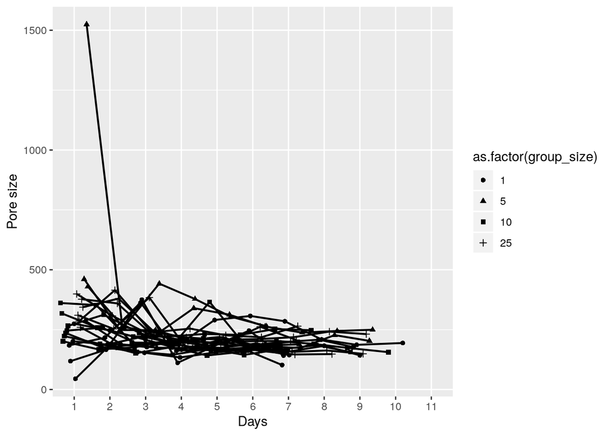

```r
pd <- position_dodge(width = 0.8)
poresize_days<-ggplot(all_web_data, aes(x=as.factor(Days), y=Pores, shape=as.factor(group_size), group=web_id)) + geom_point(position=pd)+geom_line(linetype='solid', size=0.75, position=pd) +ylab('Pore size') + xlab('Days')
poresize_days
```

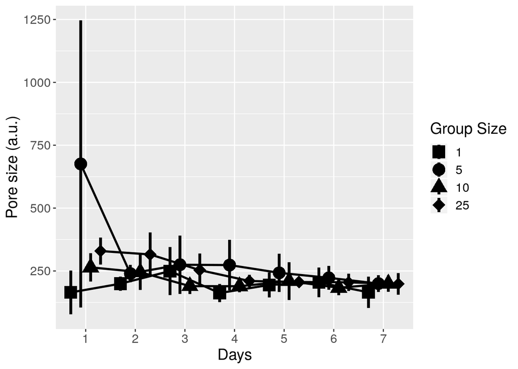

```r
# pore size which mimics layout of Figure 3 in manuscript ( length of silk vs days acros groupsizes)

# now need to make a new plot with days on x , mean + se on y axis for each group size :
poresize_mean <- aggregate(Pores ~ Days*group_size, data = all_web_data, mean, na.action=na.omit);
colnames(poresize_mean)[3] <- 'mean_poresize'
poresize_sd <-aggregate(Pores ~ Days*group_size, data = all_web_data, sd, na.action=na.omit);
colnames(poresize_sd)[3] <- 'sd_poresize'

poresize_mean_sd<-merge(poresize_mean,poresize_sd);
poresize_mean_sd<-poresize_mean_sd[order(poresize_mean_sd[,1],poresize_mean_sd[,2]),]

#
pd <- position_dodge(width = 0.8)
poresize_data<-subset(poresize_mean_sd,Days<8)


mgplt<- ggplot(poresize_data,aes(x=as.factor(Days),
                                 y=mean_poresize,
                                 shape=as.factor(group_size),
                                 group=as.factor(group_size)))+geom_pointrange(aes(ymin=mean_poresize-sd_poresize, ymax=mean_poresize+sd_poresize,width=0.9),size=1.3,position=pd) +scale_shape_manual(values=c(15,16,17,18))+ xlab('Days') + ylab('Pore size (a.u.)') +geom_line(lwd=1,position=pd)+labs(shape = "Group Size")+ theme(text = element_text(size=15));
mgplt
```

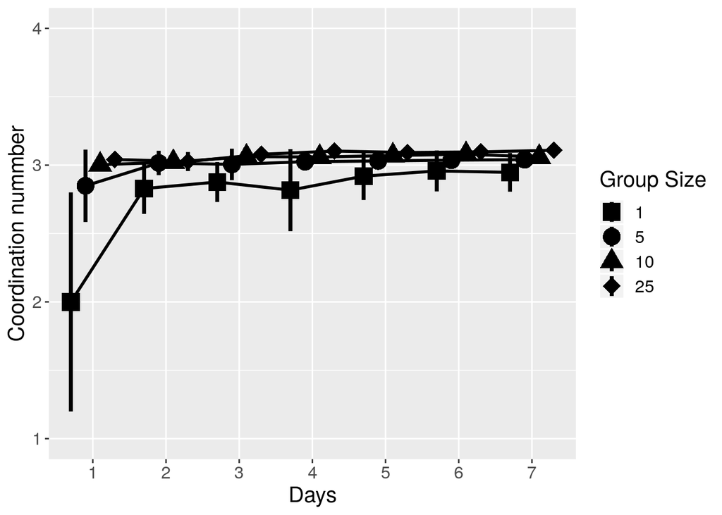

```r
# now need to make a new plot with days on x , mean + se on y axis for each group size :
coodnum_mean <- aggregate(CN ~ Days*group_size, data = all_web_data, mean, na.action=na.omit);
colnames(coodnum_mean)[3] <- 'mean_coodnum'
coodnum_sd <-aggregate(CN ~ Days*group_size, data = all_web_data, sd, na.action=na.omit);
colnames(coodnum_sd)[3] <- 'sd_coodnum'

coodnum_mean_sd<-merge(coodnum_mean,coodnum_sd);
coodnum_mean_sd<-coodnum_mean_sd[order(coodnum_mean_sd[,1],coodnum_mean_sd[,2]),]

#
coodnum_data<-subset(coodnum_mean_sd,Days<8)


mgplt2<- ggplot(coodnum_data,aes(x=as.factor(Days),
                                 y=mean_coodnum,
                                 shape=as.factor(group_size),
                                 group=as.factor(group_size)))+geom_pointrange(aes(ymin=mean_coodnum-sd_coodnum, ymax=mean_coodnum+sd_coodnum,width=0.9),size=1.3,position=pd) +scale_shape_manual(values=c(15,16,17,18))+ xlab('Days') + ylab('Coordination nummber') +geom_line(lwd=1,position=pd)+labs(shape = "Group Size")+ theme(text = element_text(size=15))+ylim(1,4);
mgplt2
```